# R Notebook

# Introduction

This project was done alongside the Tableau assignment in order to practice some R programming with exploratory data analysis. The data set used is the full superstore data containing information on there sales, profit and other metrics of their stores around the United States of America. We want to find out if the discount policy employed is beneficial or detrimental to the sales of items.

## Import pacakges for the assignment

Libraries used for our little project. Although as we move the project will add more libraries.

```r
library(tidyverse)
library(lubridate)
library(ggeasy)
```

## Extract, transform and load

Read the excel file containing the data that we are going to explore then move to tableau and create a story.

```r
df <- readxl::read_xlsx("Full-Sales-Superstore-Dataset.xlsx")
head(df)
```

| Category | City | Country | Customer Name | Manufacturer | Order Date | Order ID | Postal Code | Product Name | Region | Segment | Ship Date | Ship Mode | State | Sub-Category | Discount | Number of Records | Profit | Profit Ratio | Quantity | Sales |
| --- | --- | --- | --- | --- | --- | --- | --- | --- | --- | --- | --- | --- | --- | --- | --- | --- | --- | --- | --- | --- |
| Office Supplies | Houston | United States | Darren Powers | Message Book | 2011-01-04 | CA-2011-103800 | 77095 | Message Book, Wirebound, Four 5 1/2" X 4" Forms/Pg., 200 Dupl. Sets/Book | Central | Consumer | 2011-01-08 | Standard Class | Texas | Paper | 0.2 | 1 | 6 | 0.34 | 2 | 16 |
| Office Supplies | Naperville | United States | Phillina Ober | GBC | 2011-01-05 | CA-2011-112326 | 60540 | GBC Standard Plastic Binding Systems Combs | Central | Home Office | 2011-01-09 | Standard Class | Illinois | Binders | 0.8 | 1 | -5 | -1.55 | 2 | 4 |
| Office Supplies | Naperville | United States | Phillina Ober | Avery | 2011-01-05 | CA-2011-112326 | 60540 | Avery 508 | Central | Home Office | 2011-01-09 | Standard Class | Illinois | Labels | 0.2 | 1 | 4 | 0.36 | 3 | 12 |
| Office Supplies | Naperville | United States | Phillina Ober | SAFCO | 2011-01-05 | CA-2011-112326 | 60540 | SAFCO Boltless Steel Shelving | Central | Home Office | 2011-01-09 | Standard Class | Illinois | Storage | 0.2 | 1 | -65 | -0.24 | 3 | 273 |
| Office Supplies | Philadelphia | United States | Mick Brown | Avery | 2011-01-06 | CA-2011-141817 | 19143 | Avery Hi-Liter EverBold Pen Style Fluorescent Highlighters, 4/Pack | East | Consumer | 2011-01-13 | Standard Class | Pennsylvania | Art | 0.2 | 1 | 5 | 0.25 | 3 | 20 |
| Office Supplies | Athens | United States | Jack O'Briant | Dixon | 2011-01-07 | CA-2011-106054 | 30605 | Dixon Prang Watercolor Pencils, 10-Color Set with Brush | South | Corporate | 2011-01-08 | First Class | Georgia | Art | 0.0 | 1 | 5 | 0.41 | 3 | 13 |

Look at the data more.

```r
str(df)
```

```
tibble [9,994 x 21] (S3: tbl_df/tbl/data.frame)
 $ Category         : chr [1:9994] "Office Supplies" "Office Supplies" "Office Supplies" "Office Supplies" ...
 $ City             : chr [1:9994] "Houston" "Naperville" "Naperville" "Naperville" ...
 $ Country          : chr [1:9994] "United States" "United States" "United States" "United States" ...
 $ Customer Name    : chr [1:9994] "Darren Powers" "Phillina Ober" "Phillina Ober" "Phillina Ober" ...
 $ Manufacturer     : chr [1:9994] "Message Book" "GBC" "Avery" "SAFCO" ...
 $ Order Date       : POSIXct[1:9994], format: "2011-01-04" "2011-01-05" "2011-01-05" ...
 $ Order ID         : chr [1:9994] "CA-2011-103800" "CA-2011-112326" "CA-2011-112326" "CA-2011-112326" ...
 $ Postal Code      : num [1:9994] 77095 60540 60540 60540 19143 ...
 $ Product Name     : chr [1:9994] "Message Book, Wirebound, Four 5 1/2\" X 4\" Forms/Pg., 200 Dupl. Sets/Book" "GBC Standard Plastic Binding Systems Combs" "Avery 508" "SAFCO Boltless Steel Shelving" ...
 $ Region           : chr [1:9994] "Central" "Central" "Central" "Central" ...
 $ Segment          : chr [1:9994] "Consumer" "Home Office" "Home Office" "Home Office" ...
 $ Ship Date        : POSIXct[1:9994], format: "2011-01-08" "2011-01-09" "2011-01-09" ...
 $ Ship Mode        : chr [1:9994] "Standard Class" "Standard Class" "Standard Class" "Standard Class" ...
 $ State            : chr [1:9994] "Texas" "Illinois" "Illinois" "Illinois" ...
 $ Sub-Category     : chr [1:9994] "Paper" "Binders" "Labels" "Storage" ...
 $ Discount         : num [1:9994] 0.2 0.8 0.2 0.2 0.2 0 0 0 0 0 ...
 $ Number of Records: num [1:9994] 1 1 1 1 1 1 1 1 1 1 ...
 $ Profit           : num [1:9994] 6 -5 4 -65 5 5 9 746 1 274 ...
 $ Profit Ratio     : num [1:9994] 0.34 -1.55 0.36 -0.24 0.25 0.41 0.48 0.29 0.27 0.45 ...
 $ Quantity         : num [1:9994] 2 2 3 3 3 3 3 9 2 2 ...
 $ Sales            : num [1:9994] 16 4 12 273 20 ...
```

Generate a summary of the data.

```r
summary(df)
```

```
   Category             City             Country          Customer Name      Manufacturer
 Length:9994        Length:9994        Length:9994        Length:9994        Length:9994
 Class :character   Class :character   Class :character   Class :character   Class :character
 Mode  :character   Mode  :character   Mode  :character   Mode  :character   Mode  :character



   Order Date                    Order ID          Postal Code    Product Name          Region
 Min.   :2011-01-04 00:00:00   Length:9994        Min.   : 1040   Length:9994        Length:9994
 1st Qu.:2012-05-23 00:00:00   Class :character   1st Qu.:23223   Class :character   Class :character
 Median :2013-06-27 00:00:00   Mode  :character   Median :56431   Mode  :character   Mode  :character
 Mean   :2013-04-30 19:20:02                      Mean   :55190
 3rd Qu.:2014-05-15 00:00:00                      3rd Qu.:90008
 Max.   :2014-12-31 00:00:00                      Max.   :99301
   Segment            Ship Date                    Ship Mode            State           Sub-Category
 Length:9994        Min.   :2011-01-08 00:00:00   Length:9994        Length:9994        Length:9994
 Class :character   1st Qu.:2012-05-27 00:00:00   Class :character   Class :character   Class :character
 Mode  :character   Median :2013-06-30 00:00:00   Mode  :character   Mode  :character   Mode  :character
                    Mean   :2013-05-04 18:20:49
                    3rd Qu.:2014-05-19 00:00:00
                    Max.   :2015-01-06 00:00:00
    Discount      Number of Records     Profit          Profit Ratio        Quantity         Sales
 Min.   :0.0000   Min.   :1         Min.   :-6600.00   Min.   :-2.7500   Min.   : 1.00   Min.   :    0.0
 1st Qu.:0.0000   1st Qu.:1         1st Qu.:    2.00   1st Qu.: 0.0700   1st Qu.: 2.00   1st Qu.:   17.0
 Median :0.2000   Median :1         Median :    9.00   Median : 0.2700   Median : 3.00   Median :   54.5
 Mean   :0.1562   Mean   :1         Mean   :   28.65   Mean   : 0.1205   Mean   : 3.79   Mean   :  229.9
 3rd Qu.:0.2000   3rd Qu.:1         3rd Qu.:   29.00   3rd Qu.: 0.3600   3rd Qu.: 5.00   3rd Qu.:  210.0
 Max.   :0.8000   Max.   :1         Max.   : 8400.00   Max.   : 0.5000   Max.   :14.00   Max.   :22638.0
```

After looking at the summary of the data we see that the data has no missing values plus the data type seems to be correct. The only problem may be that the data has mixed case (uppercase or lowercase) and the column headers might need to also be change to make it easier to deal with. Below we shall change the column header to make calling the header columns easier later on.

```r
names(df)
```

```
 [1] "Category"          "City"              "Country"           "Customer Name"     "Manufacturer"
 [6] "Order Date"        "Order ID"          "Postal Code"       "Product Name"      "Region"
[11] "Segment"           "Ship Date"         "Ship Mode"         "State"             "Sub-Category"
[16] "Discount"          "Number of Records" "Profit"            "Profit Ratio"      "Quantity"
[21] "Sales"
```

Now we implement the changes mentioned above and print the results below the code cell.

```r
names(df) <- tolower(names(df))
names(df) <- gsub(" ","_", names(df),)
names(df) <- sub("-","_", names(df),)
names(df)
```

```
 [1] "category"          "city"              "country"           "customer_name"     "manufacturer"
 [6] "order_date"        "order_id"          "postal_code"       "product_name"      "region"
[11] "segment"           "ship_date"         "ship_mode"         "state"             "sub_category"
[16] "discount"          "number_of_records" "profit"            "profit_ratio"      "quantity"
[21] "sales"
```

```r
head(df)
```

| category | city | country | customer_name | manufacturer | order_date | order_id | postal_code | product_name | region | segment | ship_date | ship_mode | state | sub_category | discount | number_of_records | profit | profit_ratio | quantity | sales |
| --- | --- | --- | --- | --- | --- | --- | --- | --- | --- | --- | --- | --- | --- | --- | --- | --- | --- | --- | --- | --- |
| Office Supplies | Houston | United States | Darren Powers | Message Book | 2011-01-04 | CA-2011-103800 | 77095 | Message Book, Wirebound, Four 5 1/2" X 4" Forms/Pg., 200 Dupl. Sets/Book | Central | Consumer | 2011-01-08 | Standard Class | Texas | Paper | 0.2 | 1 | 6 | 0.34 | 2 | 16 |
| Office Supplies | Naperville | United States | Phillina Ober | GBC | 2011-01-05 | CA-2011-112326 | 60540 | GBC Standard Plastic Binding Systems Combs | Central | Home Office | 2011-01-09 | Standard Class | Illinois | Binders | 0.8 | 1 | -5 | -1.55 | 2 | 4 |
| Office Supplies | Naperville | United States | Phillina Ober | Avery | 2011-01-05 | CA-2011-112326 | 60540 | Avery 508 | Central | Home Office | 2011-01-09 | Standard Class | Illinois | Labels | 0.2 | 1 | 4 | 0.36 | 3 | 12 |
| Office Supplies | Naperville | United States | Phillina Ober | SAFCO | 2011-01-05 | CA-2011-112326 | 60540 | SAFCO Boltless Steel Shelving | Central | Home Office | 2011-01-09 | Standard Class | Illinois | Storage | 0.2 | 1 | -65 | -0.24 | 3 | 273 |
| Office Supplies | Philadelphia | United States | Mick Brown | Avery | 2011-01-06 | CA-2011-141817 | 19143 | Avery Hi-Liter EverBold Pen Style Fluorescent Highlighters, 4/Pack | East | Consumer | 2011-01-13 | Standard Class | Pennsylvania | Art | 0.2 | 1 | 5 | 0.25 | 3 | 20 |
| Office Supplies | Athens | United States | Jack O'Briant | Dixon | 2011-01-07 | CA-2011-106054 | 30605 | Dixon Prang Watercolor Pencils, 10-Color Set with Brush | South | Corporate | 2011-01-08 | First Class | Georgia | Art | 0.0 | 1 | 5 | 0.41 | 3 | 13 |

# Exploratory analysis

The questions we are going to address is how the discount affect the sales of sub-category items and the profit ratio.

```r
data_sub <- df %>% select(sub_category, sales, discount, profit, profit_ratio)
head(data_sub)
```

| sub_category | sales | discount | profit | profit_ratio |
| --- | --- | --- | --- | --- |
| Paper | 16 | 0.2 | 6 | 0.34 |
| Binders | 4 | 0.8 | -5 | -1.55 |
| Labels | 12 | 0.2 | 4 | 0.36 |
| Storage | 273 | 0.2 | -65 | -0.24 |
| Art | 20 | 0.2 | 5 | 0.25 |
| Art | 13 | 0.0 | 5 | 0.41 |

Look at the total sum of sales for each sub-category plus the profit ratio.

```r
data_sub %>% group_by(sub_category) %>% summarise(Total_sales = sum(sales), Total_profit_ratio = sum(profit_ratio),Total_discount = sum(discount), Total_profit = sum(profit)) %>% arrange(desc(Total_sales))
```

| sub_category | Total_sales | Total_profit_ratio | Total_discount | Total_profit |
| --- | --- | --- | --- | --- |
| Phones | 330047 | 106.41 | 137.40 | 44492 |
| Chairs | 328454 | 27.29 | 105.00 | 26586 |
| Storage | 223862 | 75.33 | 63.20 | 21280 |
| Tables | 206968 | -47.23 | 83.35 | -17733 |
| Binders | 203428 | -303.24 | 567.00 | 30200 |
| Machines | 189243 | -8.24 | 35.20 | 3387 |
| Accessories | 167401 | 169.11 | 60.80 | 41932 |
| Copiers | 149530 | 21.62 | 11.00 | 55618 |
| Bookcases | 114879 | -28.88 | 48.14 | -3479 |
| Appliances | 107538 | -72.98 | 77.60 | 18132 |

[output cut: 7 more lines]

Will have to change some of the data types to factors so as to simplify the visualization done below.

```r
data_sub$sub_category <- as.factor(data_sub$sub_category)
```

Visualize the total sales from largest to smallest.

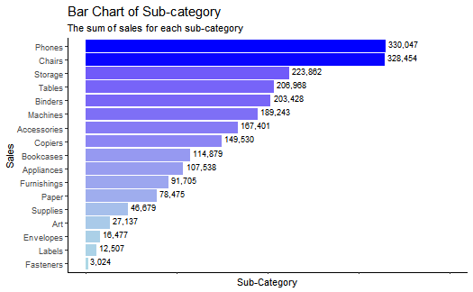

```r
data_sub %>% group_by(sub_category) %>% summarise(Total_Sales = sum(sales)) %>% ggplot(aes(x = Total_Sales, y = reorder(sub_category, Total_Sales ), fill = Total_Sales)) + geom_col() + labs(x = 'Sub-Category', subtitle = 'The sum of sales for each sub-category',y = 'Sales', title = 'Bar Chart of Sub-category') + theme_classic() + theme(legend.position = 'none', plot.title = element_text(size = 15), axis.text.x = element_blank()) + geom_text(aes(label = prettyNum(Total_Sales, big.mark = ",")), size = 3, hjust = -.1, vjust = .1) + scale_x_continuous(limits = c(0,400000)) + scale_fill_gradient(low = "light blue", high = "blue")
```

The bar chart above shows that Phones are making the highest sales and Fasteners are in last place.

Next we look at the data in terms of profit.

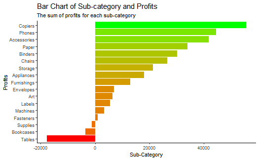

```r
data_sub %>% group_by(sub_category) %>% summarise(Total_Profit = sum(profit)) %>% ggplot(aes(x = Total_Profit, y = reorder(sub_category, Total_Profit ), fill = Total_Profit)) + geom_col() + labs(x = 'Sub-Category', subtitle = 'The sum of profits for each sub-category',y = 'Profits', title = 'Bar Chart of Sub-category and Profits')+ theme_classic() + theme(legend.position = 'none', plot.title = element_text(size = 15)) + scale_fill_gradient(low = "red" ,high = "green")
```

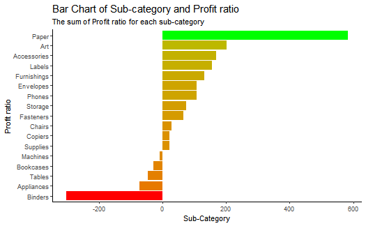

```r
data_sub %>% group_by(sub_category) %>% summarise(Total_Profit_Ratio = sum(profit_ratio)) %>% ggplot(aes(x = Total_Profit_Ratio, y = reorder(sub_category, Total_Profit_Ratio ), fill = Total_Profit_Ratio)) + geom_col() + labs(x = 'Sub-Category', subtitle = 'The sum of Profit ratio for each sub-category',y = 'Profit ratio', title = 'Bar Chart of Sub-category and Profit ratio') + theme_classic() + theme(legend.position = 'none', plot.title = element_text(size = 15)) + scale_fill_gradient(low = "red", high = "green")
```

The above shows the profit ratio of the various sub-category items. Paper leads with the highest profit ratio and blinders have the lowest profit ratio.

From the above, we shall make the sales bar graph with the profit ratio to show how the sub-category is doing in terms of profit.

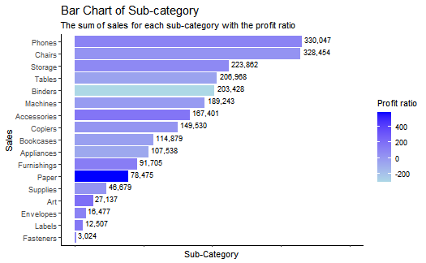

```r
data_sub %>% group_by(sub_category) %>% summarise(Total_Sales = sum(sales), Total_Profit_Ratio = sum(profit_ratio)) %>% ggplot(aes(x = Total_Sales, y = reorder(sub_category, Total_Sales ), fill = Total_Profit_Ratio)) + geom_col() + labs(x = 'Sub-Category', subtitle = 'The sum of sales for each sub-category with the profit ratio',y = 'Sales', title = 'Bar Chart of Sub-category') + theme_classic() + theme(plot.title = element_text(size = 15), axis.text.x = element_blank()) + geom_text(aes(label = prettyNum(Total_Sales, big.mark = ",")), size = 3, hjust = -.1, vjust = .1) + scale_x_continuous(limits = c(0,400000)) + scale_fill_gradient(low = "light blue", high = "blue") + easy_add_legend_title("Profit ratio")
```

From the above, paper which has a high profit ratio in terms of sales ranks low compared to binders that has a low profit ratio.

Let see how much discount binders has compared to the other sub-categories. We shall use a pie chart to illustrate this.

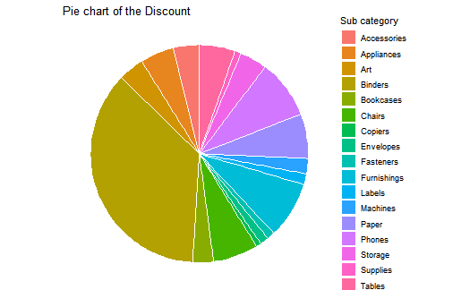

```r
 data_sub %>% group_by(sub_category) %>% summarise(Percent_discount = (sum(discount)/sum(data_sub$discount)*100)) %>% ggplot(aes(x = "", y = Percent_discount, fill = sub_category)) + geom_bar(position = "fill", stat="identity", color = "white") + coord_polar("y", start=0) + labs(title = "Pie chart of the Discount") + theme_void() + easy_add_legend_title("Sub category")
```

The pie chart clearly shows the discount of binders is greater than the rest. This is the reason that the profit ratio is the lowest from the bar chart.

After this we shall use a correlation matrix and scatter plot to identify any correlation that may exist between discount and the other attributes that we are experimenting on. An important note to mention is that correlation does not imply causation.

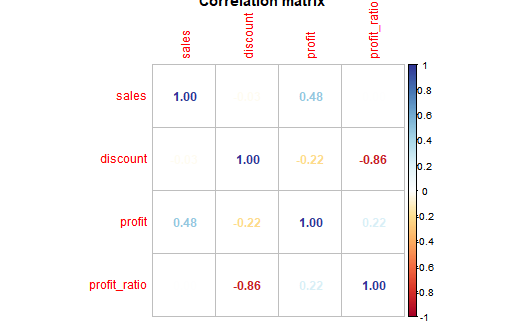

```r
library(corrplot)
num_data <- data_sub %>% select(-sub_category)
m <- cor(num_data)
corrplot(m, method = 'number', col = COL2('RdYlBu'), title = "Correlation matrix")
```

From the corrplot, we can see that there is a strong negative correlation between Profit ratio and discount (-0.86). We also see that there is a weak strong correlation between profit and sales (0.48) and a weak negative correlation between profit and discount.

Now we shall construct a scatterplot of sum of the profit ratio and discount to get a more indepth insight.

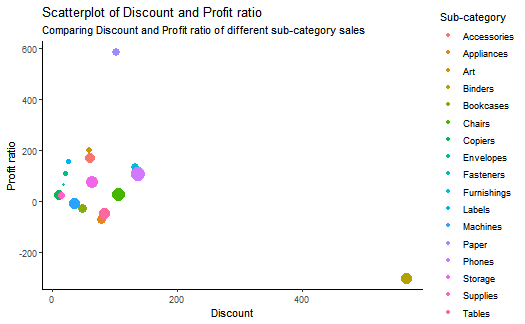

```r
data_sub %>% group_by(sub_category) %>% summarize(Total_Profit_Ratio = sum(profit_ratio), Total_discount = sum(discount), Total_sales = sum(sales)) %>% ggplot() + geom_point(aes(y = Total_Profit_Ratio, x = Total_discount, color = sub_category, size = Total_sales)) + theme_classic() + labs(title = "Scatterplot of Discount and Profit ratio", y = "Profit ratio", x = "Discount", subtitle = "Comparing Discount and Profit ratio of different sub-category sales", color = "black") + easy_add_legend_title("Sub-category") + scale_size(guide = "none")
```

From the scatterplot, we can see that for binders the discount is high therefore the profit ratio is negative. The company may need to re-evaluate the discount for binders. Lastly we construct a treemap to have a bird”s eye view of the sales.

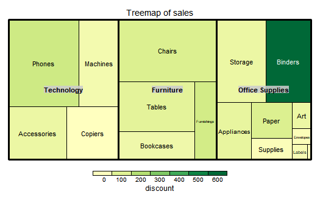

[figure not shown]

```r
#library(treemap)
#library(d3treeR)
tre <- df %>% select(category, sub_category, sales, discount)
p <- d3tree2(treemap(tre ,index = c("category", "sub_category"), vSize = "sales", vColor = "discount", type = "value", title = "Treemap of sales"), rootname = "Category")
```

```r
p
```

[interactive chart not shown]

The treemap show that the office suppiles are highly discounted compared to the other categories mainly because of blinders.

# Conclusion

Blinders seem to be doing good for sales but are highly discounted. The store may require to remove the discount on blinder to generate more profit.

# Machine learning

We want to use random tree regression to predict our profit and also gain insight on what features are important for the profit attribute.

From the whole dataset, I will remove meaningless attributes such as customer name that will not be used by the algorithm.

```r
regress <- df %>% select(-customer_name, -country, -postal_code, -city, -product_name, -number_of_records, -order_id, -segment, -ship_mode)
head(regress)
```

| category | manufacturer | order_date | region | ship_date | state | sub_category | discount | profit | profit_ratio | quantity | sales |
| --- | --- | --- | --- | --- | --- | --- | --- | --- | --- | --- | --- |
| Office Supplies | Message Book | 2011-01-04 | Central | 2011-01-08 | Texas | Paper | 0.2 | 6 | 0.34 | 2 | 16 |
| Office Supplies | GBC | 2011-01-05 | Central | 2011-01-09 | Illinois | Binders | 0.8 | -5 | -1.55 | 2 | 4 |
| Office Supplies | Avery | 2011-01-05 | Central | 2011-01-09 | Illinois | Labels | 0.2 | 4 | 0.36 | 3 | 12 |
| Office Supplies | SAFCO | 2011-01-05 | Central | 2011-01-09 | Illinois | Storage | 0.2 | -65 | -0.24 | 3 | 273 |
| Office Supplies | Avery | 2011-01-06 | East | 2011-01-13 | Pennsylvania | Art | 0.2 | 5 | 0.25 | 3 | 20 |
| Office Supplies | Dixon | 2011-01-07 | South | 2011-01-08 | Georgia | Art | 0.0 | 5 | 0.41 | 3 | 13 |

Split the data into test and train datasets.

```r
library(caret)
set.seed(25)
partition <- caret::createDataPartition(regress$profit, p = 0.75, list = FALSE)
data_train <- regress[partition,]
data_test <- regress[-partition,]
```

After splitting the data, we use the random forest algorithm to run a regression model on the data.

```r
rf.fit <- randomForest(profit ~ ., data = data_train, importance = TRUE)
rf.fit <- randomForest(profit ~ ., data = data_train, importance = TRUE)
rf.fit
```

```
Call:
 randomForest(formula = profit ~ ., data = data_train, importance = TRUE)
               Type of random forest: regression
                     Number of trees: 500
No. of variables tried at each split: 3

          Mean of squared residuals: 12108.28
                    % Var explained: 79.27
```

Display a graph of mean squared error based on the number of trees used.

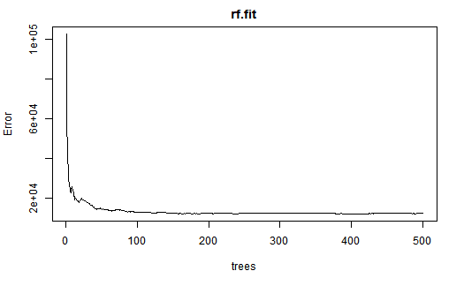

```r
plot(rf.fit)
```

Now we attempt to evaluate the random forest algorithm. First we find the smallest mean squared error produced by the algorithm.

```r
which.min(rf.fit$mse)
```

```
[1] 404
```

```r
sqrt(rf.fit$mse[which.min(rf.fit$mse)])
```

```
[1] 108.7375
```

Construct a plot showing the importance of the predictor variable.

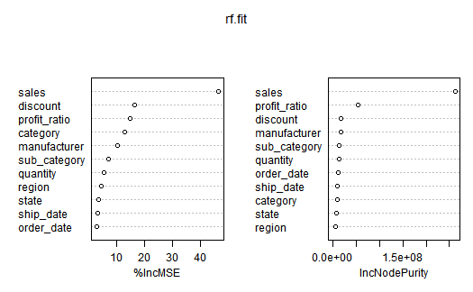

```r
varImpPlot(rf.fit)
```

Show the figures used to construct the figure above.

```r
rfvar <- varImp(rf.fit, scale = TRUE) %>% arrange(desc(Overall))
rfvar
```

|  | Overall |
| --- | --- |
| sales | 46.607122 |
| discount | 16.614670 |
| profit_ratio | 15.075511 |
| category | 13.066157 |
| manufacturer | 10.350422 |
| sub_category | 7.183620 |
| quantity | 5.479366 |
| region | 4.628343 |
| state | 3.773809 |
| ship_date | 3.256019 |

[output cut: 1 more lines]